# Summary simulation results

2020-11-06

# 1 Changelog

Main modifications with respect to previous versions:

2020-11-06

2020-10-30

- We have added new constraints on the possible correlation values. See section 2.3.
- Correction on the correlation estimator in the blinded approach. See overleaf document for further details.
- Study on the bias of the correlation estimator. See section 3.3.

2020-09-24

- The scenarios we considered for the parameters ($p_1^{(0)},p_2^{(0)},OR_1,OR_2$) are a subset of the previous version, while for the correlation ($\rho$) we have added more values.
- For the endpoint selection, we estimate the correlation at the end of the study based on two different approaches: i) using blinded data; and ii) using unblinded data. See section 2.2. for further explanation. We remark that in contrast with the previous version, we do not use the expected effect on the composite endpoint to estimate the correlation.

# 2 Design and main assumptions

We simulate a two-arm trial with two binary endpoints according to the following parameters:

- Probability endpoint 1 control group ($p_1^{(0)}$): $0.1, 0.2$;
- Probability endpoint 2 control group ($p_2^{(0)}$): $0.1, 0.25$;
- Odds ratio endpoint 1 ($OR_1$): $0.6, 0.7, 0.8$;
- Odds ratio endpoint 2 ($OR_2$): $0.75, 0.8$;
- Correlation between endpoints ($\rho$): $0, 0.1, 0.2, 0.3, 0.4, 0.5, 0.6, 0.7, 0.8$.

The correlation between the endpoints is assumed to be equal for both groups. We note that since the correlation is bounded between two values defined by ($p_1^{(0)},p_2^{(0)},OR_1,OR_2$), not all the combinations of ($p_1^{(0)},p_2^{(0)},OR_1,OR_2,\rho$) are possible. We calculate the correlation bounds for each combination of ($p_1^{(0)},p_2^{(0)},OR_1,OR_2$) and discard those scenarios in which the correlation is not within the valid range. The total number of scenarios is $183$.

We consider the composite binary endpoint formed by endpoints 1 and 2. Based on the parameters ($p_1^{(0)},p_2^{(0)},OR_1,OR_2,\rho$), we compute:

- Probability composite endpoint control group ($p_*^{(0)}$);
- Odds ratio composite endpoint ($OR_*$);

The sample size used for the simulation is calculated to have $0.80$ power to detect an effect of $OR_1$ on the endpoint 1 at significance level $\alpha = 0.05$.

## 2.1 Decision criterias

We assume that the endpoint 1 is more relevant for the clinical question than endpoint 2.

**ARE Method**:

We consider the Asymptotic Relative Efficiency (ARE) method to quantify the efficiency of using the composite endpoint over the endpoint 1 as primary endpoint of the trial. Based on the parameters ($p_1^{(0)},p_2^{(0)},OR_1,OR_2,\rho$), we compute:

- ARE value;
- ARE Decision: *CE*, if the composite endpoint is preferred; *RE*, if the endpoint 1 is preferred.

**Ratio Sample sizes**:

We calculate the sample size to have $0.80$ power to detect an effect of $OR_1$ on the endpoint 1, given the probability $p_1^{(0)}$ under the control group, at significance level $\alpha = 0.05$, say $n_1$.

We also calculate the sample size to have $0.80$ power to detect an effect of $OR_*$ on the composite endpoint, given the probability $p_*^{(0)}$ under the control group, at significance level $\alpha = 0.05$, say $n_*$. Note that for calculating the sample size for the composite endpoint have been used the values of the parameters ($p_1^{(0)},p_2^{(0)},OR_1,OR_2,\rho$).

The decision criteria is the ratio of the two sample sizes:

$$n_1 / n_*$$

so that if the ratio is smaller than $1$, we use the relevant endpoint; whereas if the ratio is larger than $1$, we use the composite endpoint.

## 2.2 Cases under study

We evaluate through simulations the statistical power and significance level under different situations and using different primary endpoints.

For each scenario, we compare the two groups based on three endpoints:

- the relevant endpoint: we consider endpoint 1 as the primary endpoint;
- the composite endpoint: we consider the composite endpoint formed by the union of endpoint 1 and endpoint 2 as the primary endpoint;
- the selected endpoint: we select the primary endpoint at the end of the trial. We do so based on the ARE method and using blinded/unblinded data to estimate the probabilities under the control group and the correlation.

Remark: we simulate $100000$ trials for each scenario and for each endpoint considered as primary endpoint;

For each scenario, we evaluate the following cases:

1. Under alternative hypothesis ($H_1$):
   1. testing the group differences based on the endpoint 1.
   2. testing the group differences based on the composite endpoint.
   3. testing the group differences based on the selected endpoint.
2. Under the null hypothesis ($H_0$):
   1. testing the group differences based on the endpoint 1.
   2. testing the group differences based on the composite endpoint.
   3. testing the group differences based on the selected endpoint.

When simulating under $H_0$, we consider $OR_1=OR_2=1$; whereas when simulating under $H_1$, we consider the following situations:

- Effect on both composite components: That is, we consider the previous mentioned values for $OR_1$, $OR_2$, and the resulting $OR_*$.
- Effect on only one component: That is, we plan the trial based on the previous mentioned values $OR_1$, $OR_2$, and the resulting $OR_*$, but we simulate that $OR_1=1$ or $OR_2=1$.

## 2.3 Estimation correlation and ARE recalculation

We consider two different approaches for estimating the correlation between the endpoints 1 and 2.

**Blinded approach**:

Based on the observed responses in the pooled sample, we estimate the probabilities $p_1$, $p_2$, and $p_*$, where $p_k=\pi p_k^{(0)} + (1-\pi)p_k^{(1)}$ for $k=1,2,*$ and $\pi=n^{(0)}/n$. Assuming the expected effects for the endpoints 1 and 2 (say $OR_1$ and $OR_2$) pre-specified in advance, we obtain estimates of the probabilities of each composite component under the control group $p_1^{(0)},p_2^{(0)}$ and subsequently the estimates of the probabilities under the treatment group $p_1^{(1)},p_2^{(1)}$.

Using the estimated probabilities for each composite component in each group ($p_1^{(0)},p_2^{(0)},p_1^{(1)},p_2^{(1)}$) and using the estimated pooled probability of the composite endpoint ($p_*$), we get an estimate of the correlation.

We calculate the ARE by using the estimated probabilities $p_1^{(0)},p_2^{(0)}$ and the estimated correlation.

**Unblinded approach**:

Based on the observed responses in patients in the control group, we estimate the probabilities $p_1^{(0)},p_2^{(0)},p_*^{(0)}$. Then, using these estimated probabilities, we obtain an estimate of the correlation between the Endpoints 1 and 2 in the control group $\rho^{(0)}$.

We do the same for the treatment group, and then we obtain an estimate of the correlation in the treatment group $\rho^{(1)}$.

We calculate the ARE by using the estimated probabilities $p_1^{(0)},p_2^{(0)}$ and the mean of the two estimates of the correlation.

## 2.4 Correlation bounds

As mentioned before, Pearson correlation coefficient between two binary endpoints takes values between two bounds: denote by $B_L(\cdot)$ the lower bound, and by $B_U(\cdot)$ the upper bound. Both $B_L(\cdot)$ and $B_U(\cdot)$ are functions of the marginal probabilities of the binary endpoints.

Thus, in our context, the correlation between endpoints 1 and 2 in the control group lies within $B_L(p_1^{(0)},p_2^{(0)})$ and $B_U(p_1^{(0)},p_2^{(0)})$; whereas the correlation between them in the treatment group takes values between $B_L(p_1^{(1)},p_2^{(1)})$ and $B_U(p_1^{(1)},p_2^{(1)})$.

Since we assume that the correlation is the same in both treatment groups, we require that:

$$max(B_L(p_1^{(0)},p_2^{(0)}),B_L(p_1^{(1)},p_2^{(1)})) \leq \rho \leq min(B_U(p_1^{(0)},p_2^{(0)}),B_U(p_1^{(1)},p_2^{(1)}))$$

In the estimation approaches explained above, we compute the correlation bounds based on the estimated probabilities and force the estimated correlation to take values within this interval. We notice that this interval can be different from the one calculated based on the true probabilities (those used to run the simulations).

# 3 Results

## 3.1 Under alternative hypothesis ($H_1$)

### 3.1.1 Cases (1a) and (1b)

In what follows we compare the statistical powers obtained using the composite endpoint with the ones obtained using the endpoint 1 as primary endpoint. We also evaluate the concordance between the choice of the primary endpoint -according to the ARE value and the ratio of the sample sizes- and the difference in powers obtained in the simulation. In this case, we calculate the ARE at the beginning of the study, and then according to the parameters ($p_1^{(0)},p_2^{(0)},OR_1,OR_2,\rho$).

```r
dataset$diff_powers = dataset$Test_Power_CE - dataset$Test_Power_RE
```

The following plot shows the relationship between the ARE value and the difference in power between using the composite endpoint (CE) or using the endpoint 1 (RE).

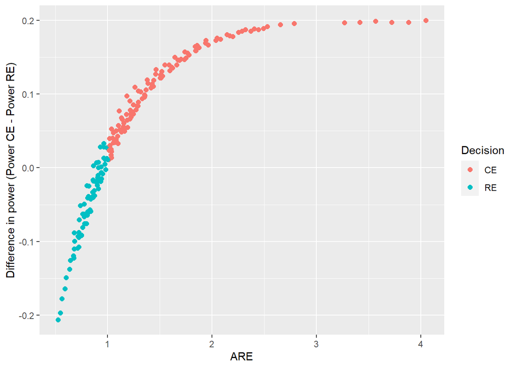

```r
ggplot(dataset, aes(x=ARE, y=diff_powers, color=as.factor(decision))) + geom_point(size=2) + labs(y = "Difference in power (Power CE - Power RE)", x="ARE", color="Decision")
```

Cases in which there is no concordance between the decision and the power gain:

```r
dataset$gain_power = ifelse(dataset$diff_powers>0, "CE", "RE")
dataset$gain_power = as.factor(dataset$gain_power)
dataset$decision = as.factor(dataset$decision)

summary(subset(dataset,dataset$gain_power != dataset$decision)[,c(3,4,18,19,20,21,22)])
```

```
##       OR1              OR2              ARE         decision samplesize_e1
##  Min.   :0.6000   Min.   :0.7500   Min.   :0.8664   CE: 0    Min.   : 714
##  1st Qu.:0.6000   1st Qu.:0.7500   1st Qu.:0.9314   RE:13    1st Qu.:1335
##  Median :0.6000   Median :0.7500   Median :0.9653            Median :1335
##  Mean   :0.6308   Mean   :0.7692   Mean   :0.9525            Mean   :1293
##  3rd Qu.:0.7000   3rd Qu.:0.8000   3rd Qu.:0.9769            3rd Qu.:1374
##  Max.   :0.7000   Max.   :0.8000   Max.   :0.9999            Max.   :2532
##  Test_Power_CE    Test_Power_RE
##  Min.   :0.8067   Min.   :0.8005
##  1st Qu.:0.8101   1st Qu.:0.8025
##  Median :0.8137   Median :0.8038
##  Mean   :0.8182   Mean   :0.8037
##  3rd Qu.:0.8312   3rd Qu.:0.8050
##  Max.   :0.8392   Max.   :0.8067
```

### 3.1.2 Case (1c)

The following figure illustrates the empirical power we obtained using the composite endpoint (CE), the endpoint 1 (RE) or the selected endpoint (SE).

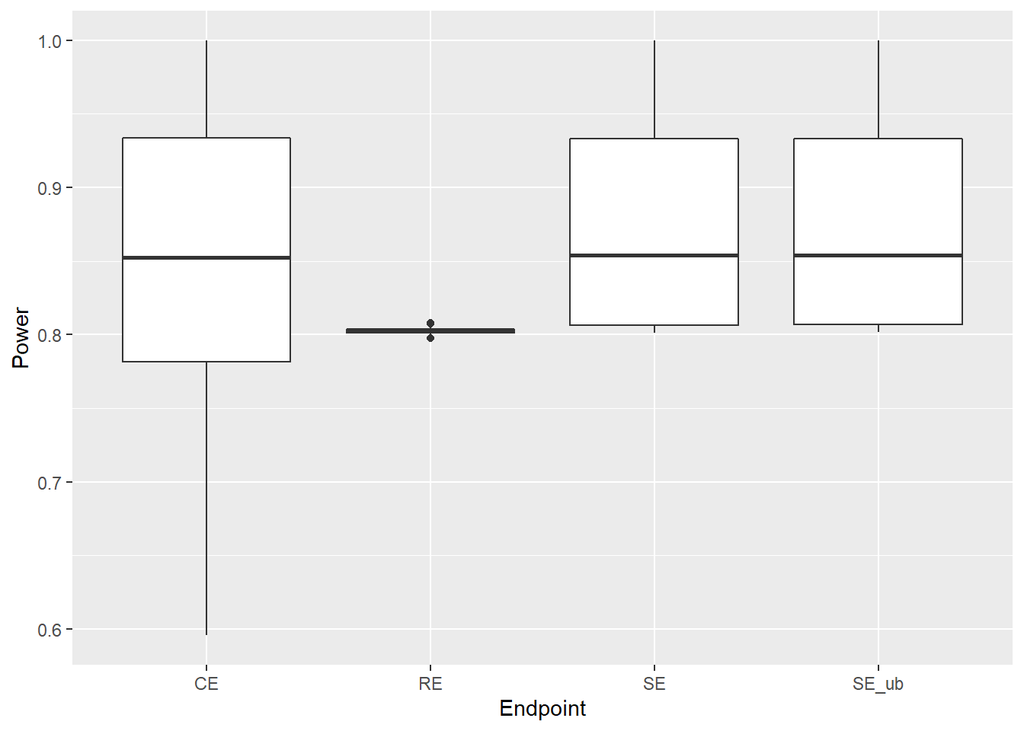

```r
subd=dataset#subset(dataset,is.na(dataset$Test_Power_ES_ub)==F)

power_data <- data.frame(Power=c(dataset$Test_Power_ES,dataset$Test_Power_ES_ub,dataset$Test_Power_CE,dataset$Test_Power_RE),
                         Endpoint=c(rep("SE",length(dataset$Test_Power_ES)),
                                    rep("SE_ub",length(dataset$Test_Power_ES_ub)),
                                    rep("CE",length(dataset$Test_Power_CE)),
                                    rep("RE",length(dataset$Test_Power_RE)))
)

ggplot(power_data, aes(x=Endpoint, y=Power)) + geom_boxplot()
```

### 3.1.3 Comparing empirical powers

For each combination of ($p_1^{(0)},p_2^{(0)},OR_1,OR_2$), we plot the empirical power for each design -Selected Endpoint with blinded estimation (SE), Selected Endpoint with unblinded estimation (SE_u), Composite Endpoint (CE), and Relevant Endpoint (RE)- according to the correlation $\rho$. In the empirical powers for the Selected Endpoint, we plot the points in different colors depending on which endpoint would have been chosen using the ARE calculated from the *true* parameters ($p_1^{(0)},p_2^{(0)},OR_1,OR_2,\rho$).

For each combination of ($p_1^{(0)},p_2^{(0)},OR_1,OR_2$), we also present a table with:

1. **Corr**: The values considered for the correlation in this scenario;
2. **ARE**: The value of the ARE computed using the parameters used in the design, i.e., ($p_1^{(0)},p_2^{(0)},OR_1,OR_2$) and $\rho$;
3. **%CE**: The percentage of cases over the 100000 replications in which the selected endpoint was the composite endpoint using blinded data;
4. **%CE_u**: The percentage of cases over the 100000 replications in which the selected endpoint was the composite endpoint using unblinded data.

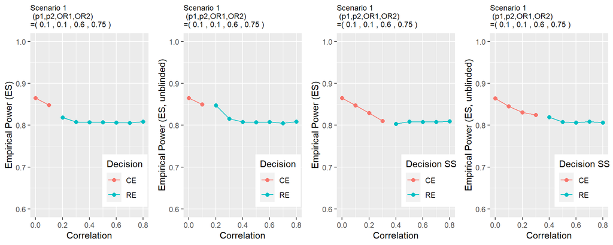

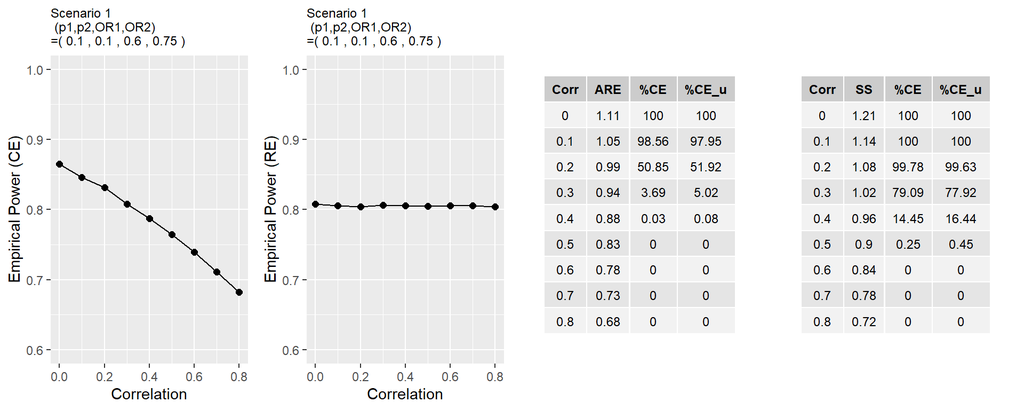

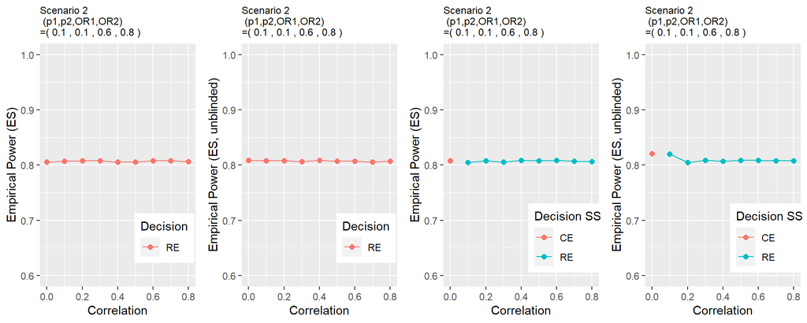

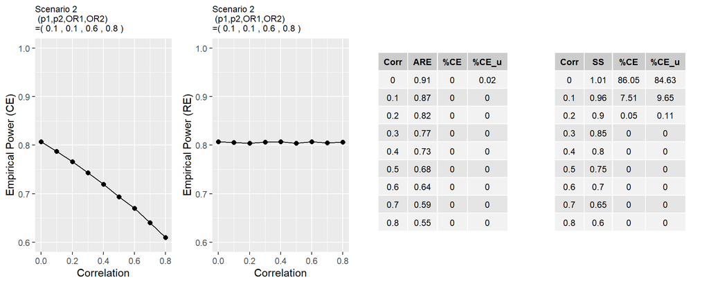

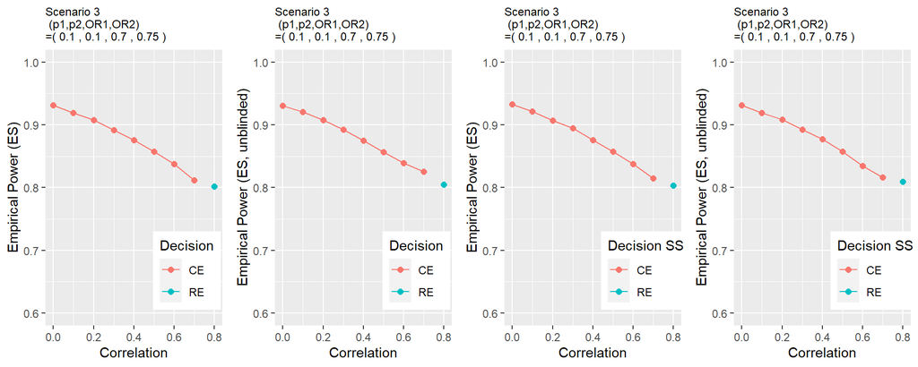

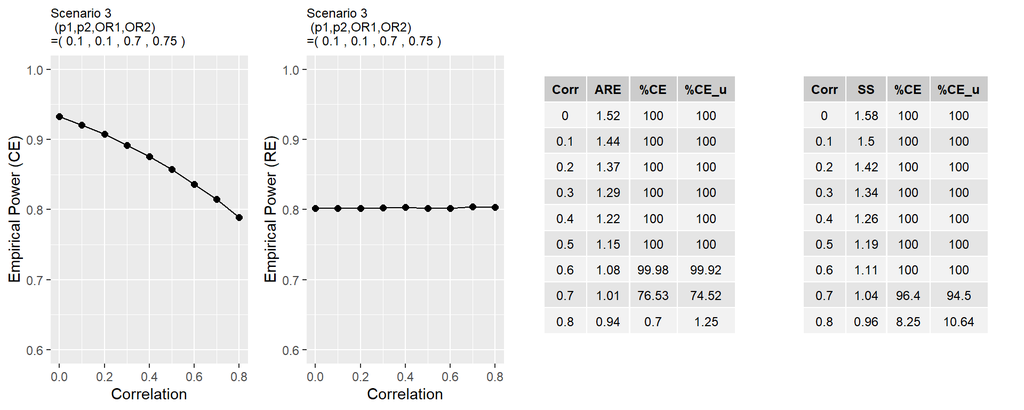

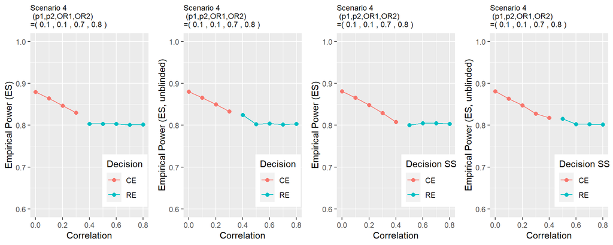

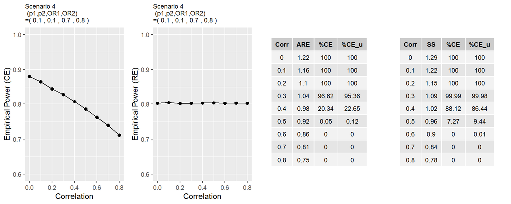

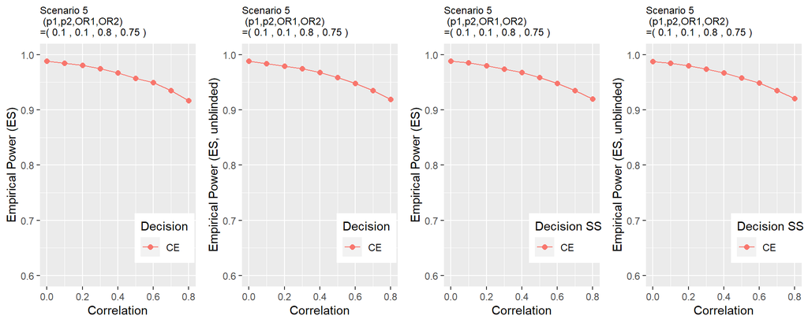

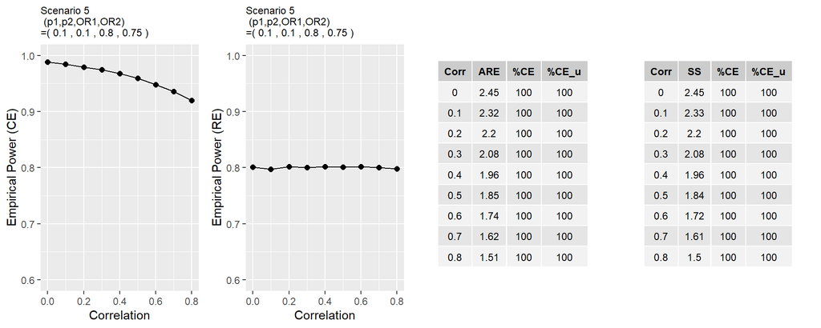

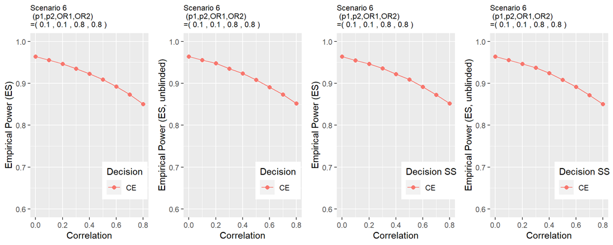

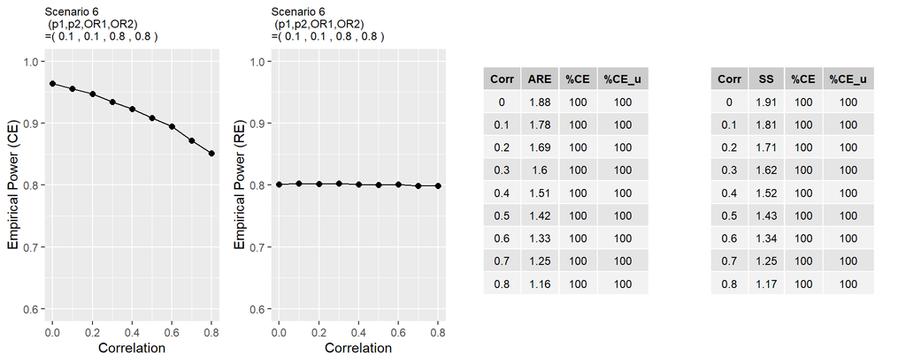

[36 more figures not shown]

```r
p <- list()
enum = 1
it <- 1
for(i in 1:max(dataset$scenario)){
  sub=subset(dataset,dataset$scenario==i)
  #
  p[[enum]] <-ggplot(sub, aes(x=corr, y=Test_Power_ES, color=as.factor(decision)))  +
    geom_point(size=2)+ ggtitle(paste("Scenario", dataset$scenario[it], "\n (p1,p2,OR1,OR2) \n=(", dataset$p0_e1[it],",",dataset$p0_e2[it],",",dataset$OR1[it],",",dataset$OR2[it],")"))+geom_point(size=2)  + labs(y = "Empirical Power (ES)", x="Correlation", color="Decision") + coord_cartesian(ylim = c(0.60, 1))+ geom_path()+ theme(plot.title = element_text(size=9),legend.position = c(0.8, 0.2))
  p[[enum+1]] <-ggplot(sub, aes(x=corr, y=Test_Power_ES_ub, color=as.factor(decision)))  +
    geom_point(size=2)+ ggtitle(paste("Scenario", dataset$scenario[it], "\n (p1,p2,OR1,OR2) \n=(", dataset$p0_e1[it],",",dataset$p0_e2[it],",",dataset$OR1[it],",",dataset$OR2[it],")"))+geom_point(size=2)  + labs(y = "Empirical Power (ES, unblinded)", x="Correlation", color="Decision") + coord_cartesian(ylim = c(0.60, 1))+ geom_path()+ theme(plot.title = element_text(size=9),legend.position = c(0.8, 0.2))
  #
  p[[enum+2]] <-ggplot(sub, aes(x=corr, y=Test_Power_ES_bSS, color=as.factor(ss_decision)))  +
    geom_point(size=2)+ ggtitle(paste("Scenario", dataset$scenario[it], "\n (p1,p2,OR1,OR2) \n=(", dataset$p0_e1[it],",",dataset$p0_e2[it],",",dataset$OR1[it],",",dataset$OR2[it],")"))+geom_point(size=2)  + labs(y = "Empirical Power (ES)", x="Correlation", color="Decision SS") + coord_cartesian(ylim = c(0.60, 1))+ geom_path()+ theme(plot.title = element_text(size=9),legend.position = c(0.8, 0.2))
  p[[enum+3]] <-ggplot(sub, aes(x=corr, y=Test_Power_ES_ubSS, color=as.factor(ss_decision)))  +
    geom_point(size=2)+ ggtitle(paste("Scenario", dataset$scenario[it], "\n (p1,p2,OR1,OR2) \n=(", dataset$p0_e1[it],",",dataset$p0_e2[it],",",dataset$OR1[it],",",dataset$OR2[it],")"))+geom_point(size=2)  + labs(y = "Empirical Power (ES, unblinded)", x="Correlation", color="Decision SS") + coord_cartesian(ylim = c(0.60, 1))+ geom_path()+ theme(plot.title = element_text(size=9),legend.position = c(0.8, 0.2))
  #
  p[[enum+4]] <-ggplot(sub, aes(x=corr, y=Test_Power_CE))  +
    geom_point(size=2)+ ggtitle(paste("Scenario", dataset$scenario[it], "\n (p1,p2,OR1,OR2) \n=(", dataset$p0_e1[it],",",dataset$p0_e2[it],",",dataset$OR1[it],",",dataset$OR2[it],")"))+geom_point(size=2)  + labs(y = "Empirical Power (CE)", x="Correlation", color="Decision") + coord_cartesian(ylim = c(0.60, 1))+ geom_path()+ theme(plot.title = element_text(size=9))
  p[[enum+5]] <-ggplot(sub, aes(x=corr, y=Test_Power_RE))  +
    geom_point(size=2)+ ggtitle(paste("Scenario", dataset$scenario[it], "\n (p1,p2,OR1,OR2) \n=(", dataset$p0_e1[it],",",dataset$p0_e2[it],",",dataset$OR1[it],",",dataset$OR2[it],")"))+geom_point(size=2)  + labs(y = "Empirical Power (RE)", x="Correlation", color="Decision") + coord_cartesian(ylim = c(0.60, 1))+ geom_path()+ theme(plot.title = element_text(size=9))

  stable <- data.frame(Corr=sub$corr,
                       ARE=round(sub$ARE,2),"%CE"=round(100*sub$decision_ES,2),
                       "%CE_u"=round(100*sub$decision_ES_ub,2),check.names=FALSE)

  p[[enum+6]] <- ggtexttable(stable, rows = NULL, theme = ttheme(base_style = "default", base_size = 9))

  stable <- data.frame(Corr=sub$corr,
                       SS=round(sub$ss_ratio,2),"%CE"=round(100*sub$decision_ES_bSS,2),
                       "%CE_u"=round(100*sub$decision_ES_ubSS,2),check.names=FALSE)

  p[[enum+7]] <- ggtexttable(stable, rows = NULL, theme = ttheme(base_style = "default", base_size = 9))

  enum=enum+8
  it <- it + dim(subset(dataset,dataset$scenario==i))
}
marrangeGrob(p,ncol=4,nrow=1,top=NULL)
```

```r
# ,heights = c(5, 10)
```

### 3.1.4 Additional scenarios

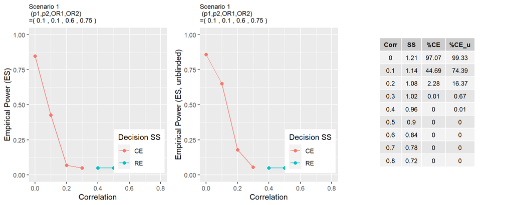

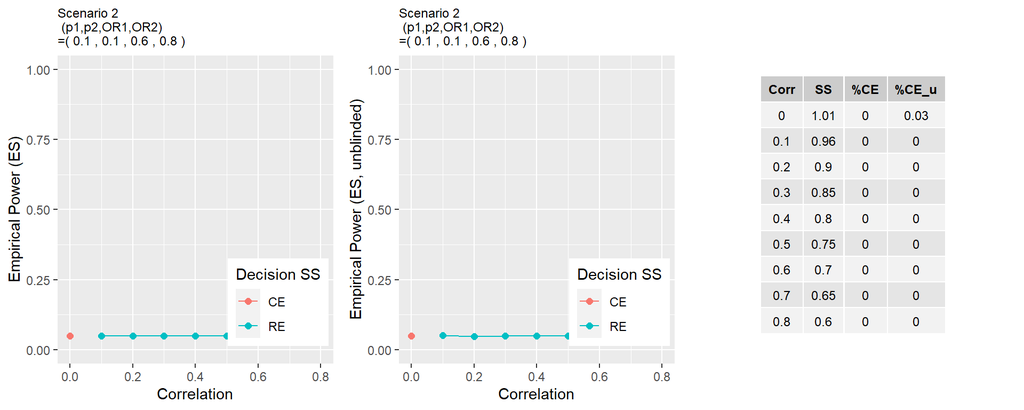

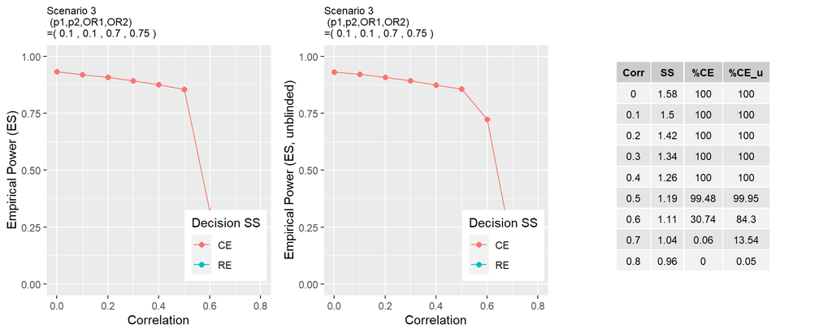

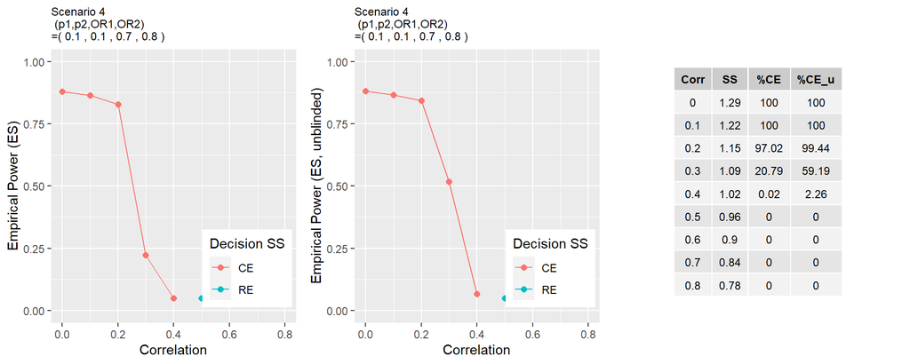

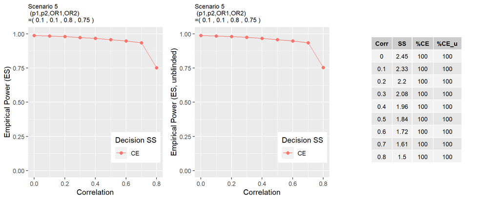

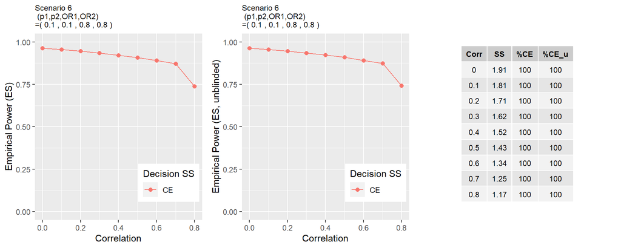

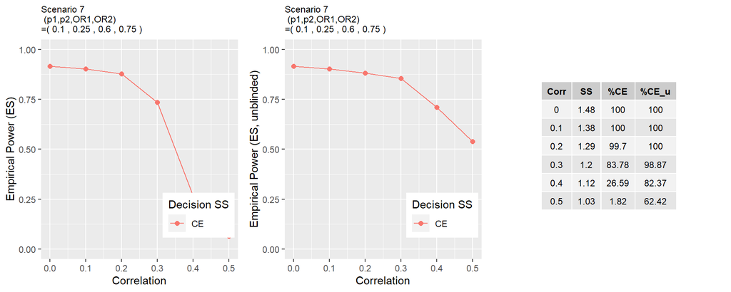

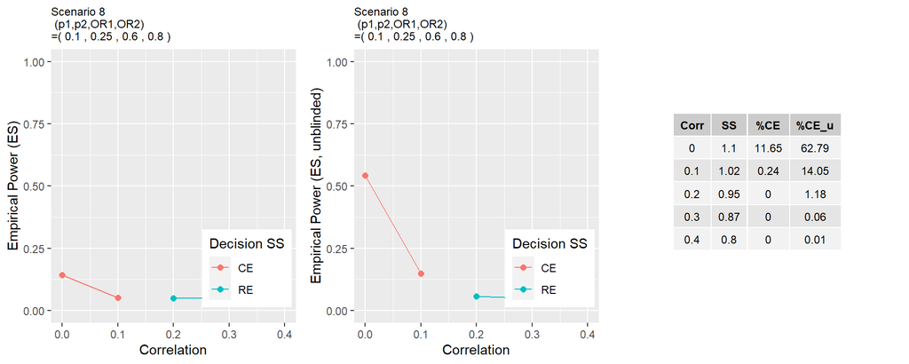

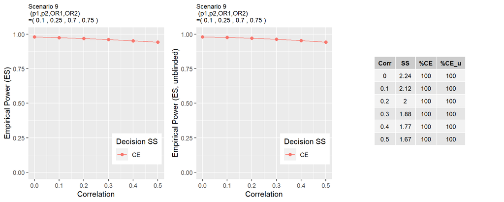

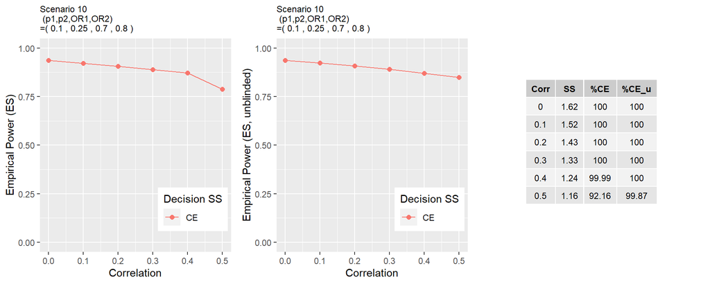

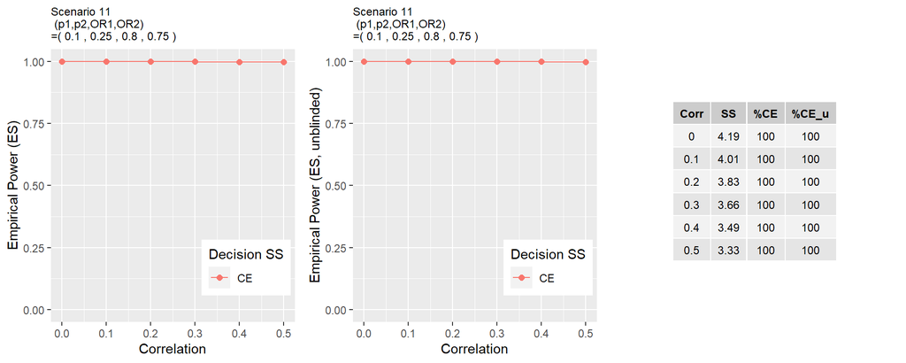

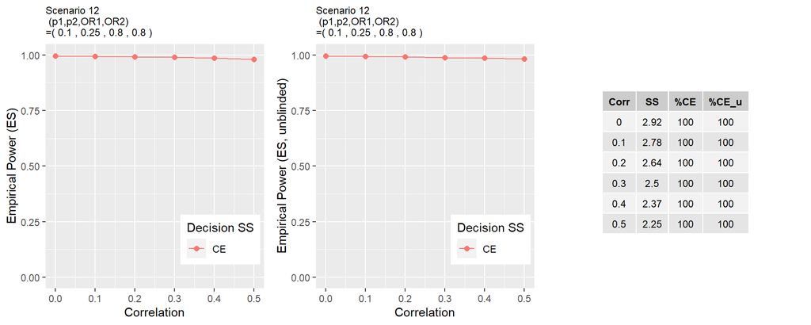

[12 more figures not shown]

```r
p <- list()
enum = 1
it <- 1
for(i in 1:max(dataset_SSadd$scenario)){
  sub=subset(dataset_SSadd,dataset_SSadd$scenario==i)
  # sub=subset(dataset,dataset$scenario==i)
  #

  p[[enum]] <-ggplot(sub, aes(x=corr, y=Test_Power_ES_bSS, color=as.factor(ss_decision)))  +
    geom_point(size=2)+ ggtitle(paste("Scenario", dataset_SSadd$scenario[it], "\n (p1,p2,OR1,OR2) \n=(", dataset_SSadd$p0_e1[it],",",dataset_SSadd$p0_e2[it],",",dataset_SSadd$OR1[it],",",dataset_SSadd$OR2[it],")"))+geom_point(size=2)  + labs(y = "Empirical Power (ES)", x="Correlation", color="Decision SS") + coord_cartesian(ylim = c(0, 1))+ geom_path()+ theme(plot.title = element_text(size=9),legend.position = c(0.8, 0.2))
  p[[enum+1]] <-ggplot(sub, aes(x=corr, y=Test_Power_ES_ubSS, color=as.factor(ss_decision)))  +
    geom_point(size=2)+ ggtitle(paste("Scenario", dataset_SSadd$scenario[it], "\n (p1,p2,OR1,OR2) \n=(", dataset_SSadd$p0_e1[it],",",dataset_SSadd$p0_e2[it],",",dataset_SSadd$OR1[it],",",dataset_SSadd$OR2[it],")"))+geom_point(size=2)  + labs(y = "Empirical Power (ES, unblinded)", x="Correlation", color="Decision SS") + coord_cartesian(ylim = c(0, 1))+ geom_path()+ theme(plot.title = element_text(size=9),legend.position = c(0.8, 0.2))
  #
  # p[[enum+2]] <-ggplot(sub, aes(x=corr, y=Test_Power_CE))  +
  #   geom_point(size=2)+ ggtitle(paste("Scenario", dataset$scenario[it], "\n (p1,p2,OR1,OR2) \n=(", dataset$p0_e1[it],",",dataset$p0_e2[it],",",dataset$OR1[it],",",dataset$OR2[it],")"))+geom_point(size=2)  + labs(y = "Empirical Power (CE)", x="Correlation", color="Decision") + coord_cartesian(ylim = c(0.60, 1))+ geom_path()+ theme(plot.title = element_text(size=9))
  # p[[enum+3]] <-ggplot(sub, aes(x=corr, y=Test_Power_RE))  +
  #   geom_point(size=2)+ ggtitle(paste("Scenario", dataset$scenario[it], "\n (p1,p2,OR1,OR2) \n=(", dataset$p0_e1[it],",",dataset$p0_e2[it],",",dataset$OR1[it],",",dataset$OR2[it],")"))+geom_point(size=2)  + labs(y = "Empirical Power (RE)", x="Correlation", color="Decision") + coord_cartesian(ylim = c(0.60, 1))+ geom_path()+ theme(plot.title = element_text(size=9))

  stable <- data.frame(Corr=sub$corr,
                       SS=round(sub$ss_ratio,2),"%CE"=round(100*sub$decision_ES_bSS,2),
                       "%CE_u"=round(100*sub$decision_ES_ubSS,2),check.names=FALSE)

  p[[enum+2]] <- ggtexttable(stable, rows = NULL, theme = ttheme(base_style = "default", base_size = 9))

  enum=enum+3
  it <- it + dim(subset(dataset_SSadd,dataset_SSadd$scenario==i))
}
marrangeGrob(p,ncol=3,nrow=1,top=NULL)
```

```r
# ,heights = c(5, 10)
```

## 3.2 Under the null hypothesis ($H_0$)

### 3.2.1 Cases (2a), (2b), and (2c)

The following boxplots show the significance level obtained using the composite endpoint (CE), the endpoint 1 (RE) or the selected endpoint (SE).

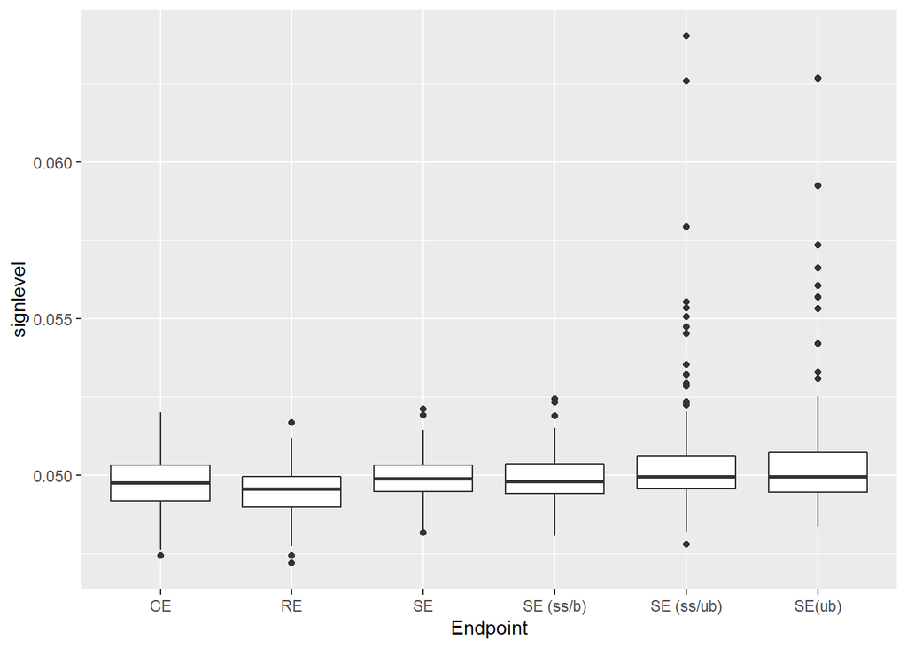

```r
signlevel_data <- data.frame(signlevel=c(dataset$Test_Reject_ES,
                                         dataset$Test_Reject_ES_ub,
                                         dataset$Test_Reject_ES_bSS,
                                         dataset$Test_Reject_ES_ubSS,
                                         dataset$Test_Reject_CE,dataset$Test_Reject_RE),
                             Endpoint=c(rep("SE",length(dataset$Test_Power_ES)),
                                        rep("SE(ub)",length(dataset$Test_Reject_ES_ub)),
                                        rep("SE (ss/b)",length(dataset$Test_Reject_ES_bSS)),
                                        rep("SE (ss/ub)",length(dataset$Test_Reject_ES_ubSS)),
                                        rep("CE",length(dataset$Test_Power_CE)),
                                        rep("RE",length(dataset$Test_Power_RE)))
                             )

ggplot(signlevel_data, aes(x=Endpoint, y=signlevel)) + geom_boxplot()
```

```r
summary(dataset[,27:30])
```

```
##  Test_Reject_CE    Test_Reject_RE    Test_Reject_ES    Test_Reject_ES_ub
##  Min.   :0.04744   Min.   :0.04720   Min.   :0.04818   Min.   :0.04835
##  1st Qu.:0.04919   1st Qu.:0.04900   1st Qu.:0.04949   1st Qu.:0.04947
##  Median :0.04976   Median :0.04957   Median :0.04990   Median :0.04997
##  Mean   :0.04974   Mean   :0.04949   Mean   :0.04992   Mean   :0.05039
##  3rd Qu.:0.05034   3rd Qu.:0.04996   3rd Qu.:0.05033   3rd Qu.:0.05074
##  Max.   :0.05201   Max.   :0.05169   Max.   :0.05212   Max.   :0.06267
```

```r
summary(data.frame(Test_Reject_ES_bSS=dataset$Test_Reject_ES_bSS,Test_Reject_ES_ubSS=dataset$Test_Reject_ES_ubSS))
```

```
##  Test_Reject_ES_bSS Test_Reject_ES_ubSS
##  Min.   :0.04808    Min.   :0.04782
##  1st Qu.:0.04942    1st Qu.:0.04957
##  Median :0.04982    Median :0.04996
##  Mean   :0.04986    Mean   :0.05045
##  3rd Qu.:0.05036    3rd Qu.:0.05063
##  Max.   :0.05244    Max.   :0.06402
```

Summary cases type 1 error rate$>0.055$ with SE(ub):

```r
# summary(subset(dataset,dataset[,30]>0.055))
subset(dataset,dataset[,30]>0.055)[,c(1,2,3,4,14,15,16,17,18)]
```

```
##     p0_e1 p0_e2 OR1  OR2 corr     p0_ce      p1_ce     OR_ce       ARE
## 3     0.1  0.10 0.6 0.75  0.2 0.1720000 0.12171499 0.6671300 0.9935465
## 26    0.1  0.10 0.7 0.75  0.7 0.1270000 0.09527059 0.7238535 1.0113052
## 58    0.1  0.25 0.6 0.75  0.3 0.2860289 0.22095262 0.7079557 1.0372446
## 59    0.1  0.25 0.6 0.75  0.4 0.2730385 0.21127017 0.7131773 0.9657080
## 77    0.1  0.25 0.7 0.80  0.5 0.2600481 0.21475252 0.7781826 1.0570704
## 155   0.2  0.25 0.7 0.75  0.7 0.2787564 0.21946178 0.7274812 0.9998902
## 159   0.2  0.25 0.7 0.80  0.2 0.3653590 0.29907843 0.7411805 1.0219000
```

## 3.3 On the bias of the correlation estimator

We ran an extra simulation to assess the correlation estimator in both blinded and unblinded approaches. Using the same scenarios we considered before, we simulate each scenario $nsim = 1000$ times. For each run, we estimate the correlation using the blinded and unblinded approach. We then compute the mean and variance of these estimators. We compute the bias as the difference between the mean value and the true value of the correlation in that scenario.

Scatterplots estimated correlation vs true correlation:

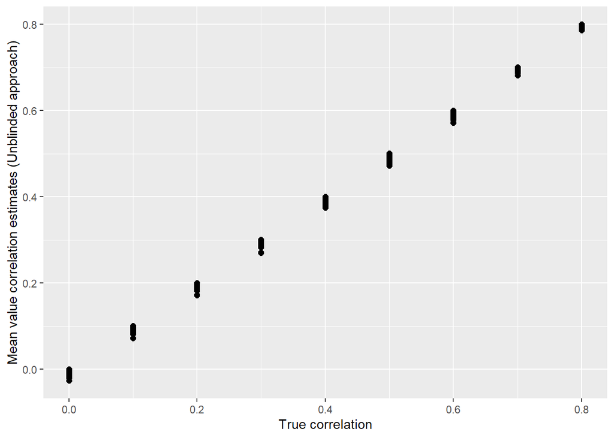

```r
ggplot(dataset, aes(x=corr, y=corr_est_ub_mean)) + geom_point(size=2) + labs(y = "Mean value correlation estimates (Unblinded approach)", x="True correlation")
```

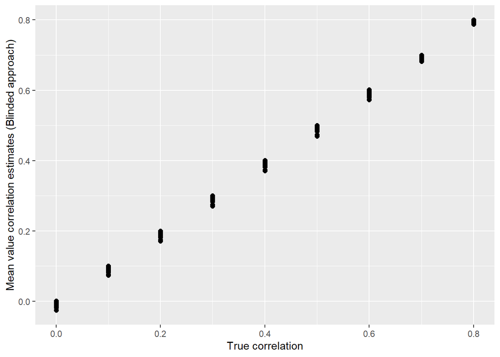

```r
ggplot(dataset, aes(x=corr, y=corr_est_b_mean)) + geom_point(size=2) + labs(y = "Mean value correlation estimates (Blinded approach)", x="True correlation")
```

Summary bias:

```r
# summary(dataset$corr)
# summary(dataset[,31:36])
summary(dataset[,35:36])
```

```
##    biased_ub             biased_b
##  Min.   :-0.0294100   Min.   :-0.030387
##  1st Qu.:-0.0120537   1st Qu.:-0.011603
##  Median :-0.0044452   Median :-0.004128
##  Mean   :-0.0074524   Mean   :-0.007285
##  3rd Qu.:-0.0015297   3rd Qu.:-0.001560
##  Max.   : 0.0008374   Max.   : 0.001313
```

# 4 Decision criteria

```r
summary(dataset)
```

```
##      p0_e1            p0_e2             OR1              OR2
##  Min.   :0.1000   Min.   :0.1000   Min.   :0.6000   Min.   :0.7500
##  1st Qu.:0.1000   1st Qu.:0.1000   1st Qu.:0.6000   1st Qu.:0.7500
##  Median :0.2000   Median :0.1000   Median :0.7000   Median :0.7500
##  Mean   :0.1514   Mean   :0.1713   Mean   :0.7016   Mean   :0.7749
##  3rd Qu.:0.2000   3rd Qu.:0.2500   3rd Qu.:0.8000   3rd Qu.:0.8000
##  Max.   :0.2000   Max.   :0.2500   Max.   :0.8000   Max.   :0.8000
##     scenario         p1_e1             p1_e2           min_corr0
##  Min.   : 1.00   Min.   :0.06250   Min.   :0.07692   Min.   :-0.2887
##  1st Qu.: 6.00   1st Qu.:0.07216   1st Qu.:0.07692   1st Qu.:-0.2887
##  Median :13.00   Median :0.13043   Median :0.08163   Median :-0.1667
##  Mean   :12.55   Mean   :0.11169   Mean   :0.13914   Mean   :-0.1899
##  3rd Qu.:19.00   3rd Qu.:0.14894   3rd Qu.:0.20000   3rd Qu.:-0.1111
##  Max.   :24.00   Max.   :0.16667   Max.   :0.21053   Max.   :-0.1111
##    min_corr1          max_corr0        max_corr1         min_corr
##  Min.   :-0.23094   Min.   :0.5774   Min.   :0.5000   Min.   :-0.23094
##  1st Qu.:-0.19365   1st Qu.:0.6667   1st Qu.:0.6667   1st Qu.:-0.19365
##  Median :-0.12910   Median :0.8660   Median :0.7746   Median :-0.12910
##  Mean   :-0.13981   Mean   :0.8046   Mean   :0.7780   Mean   :-0.13981
##  3rd Qu.:-0.08889   3rd Qu.:1.0000   3rd Qu.:0.8944   3rd Qu.:-0.08889
##  Max.   :-0.07454   Max.   :1.0000   Max.   :1.0000   Max.   :-0.07454
##     max_corr           corr            p0_ce            p1_ce
##  Min.   :0.5000   Min.   :0.0000   Min.   :0.1180   Min.   :0.08301
##  1st Qu.:0.6667   1st Qu.:0.1000   1st Qu.:0.1810   1st Qu.:0.13993
##  Median :0.7746   Median :0.3000   Median :0.2614   Median :0.21005
##  Mean   :0.7664   Mean   :0.3426   Mean   :0.2523   Mean   :0.19945
##  3rd Qu.:0.8660   3rd Qu.:0.5000   3rd Qu.:0.3120   3rd Qu.:0.24766
##  Max.   :1.0000   Max.   :0.8000   Max.   :0.4000   Max.   :0.34211
##      OR_ce             ARE         decision samplesize_e1  Test_Power_CE
##  Min.   :0.6321   Min.   :0.5253   CE:111   Min.   : 714   Min.   :0.5957
##  1st Qu.:0.7023   1st Qu.:0.8743   RE: 72   1st Qu.:1335   1st Qu.:0.7818
##  Median :0.7325   Median :1.1106            Median :2532   Median :0.8524
##  Mean   :0.7323   Mean   :1.3089            Mean   :2563   Mean   :0.8510
##  3rd Qu.:0.7702   3rd Qu.:1.5224            3rd Qu.:3340   3rd Qu.:0.9335
##  Max.   :0.7995   Max.   :4.0514            Max.   :6072   Max.   :0.9998
##  Test_Power_RE    Test_Power_ES    Test_Power_ES_ub  decision_ES
##  Min.   :0.7975   Min.   :0.8012   Min.   :0.8017   Min.   :0.0000
##  1st Qu.:0.8014   1st Qu.:0.8066   1st Qu.:0.8068   1st Qu.:0.0000
##  Median :0.8024   Median :0.8540   Median :0.8541   Median :1.0000
##  Mean   :0.8026   Mean   :0.8719   Mean   :0.8736   Mean   :0.6167
```

[output cut: 29 more lines]

```
##  Max.   :4.1944                      Max.   :0.9997     Max.   :0.9997
##  decision_ES_ubSS  decision_ES_bSS   Test_Reject_ES_ubSS Test_Reject_ES_bSS
##  Min.   :0.00000   Min.   :0.00000   Min.   :0.04782     Min.   :0.04808
##  1st Qu.:0.06731   1st Qu.:0.05038   1st Qu.:0.04957     1st Qu.:0.04942
##  Median :1.00000   Median :1.00000   Median :0.04996     Median :0.04982
##  Mean   :0.68850   Mean   :0.68790   Mean   :0.05045     Mean   :0.04986
##  3rd Qu.:1.00000   3rd Qu.:1.00000   3rd Qu.:0.05063     3rd Qu.:0.05036
##  Max.   :1.00000   Max.   :1.00000   Max.   :0.06402     Max.   :0.05244
##   diff_powers       gain_power
##  Min.   :-0.20628   CE:124
##  1st Qu.:-0.02122   RE: 59
##  Median : 0.05188
##  Mean   : 0.04841
##  3rd Qu.: 0.13119
##  Max.   : 0.19967
```

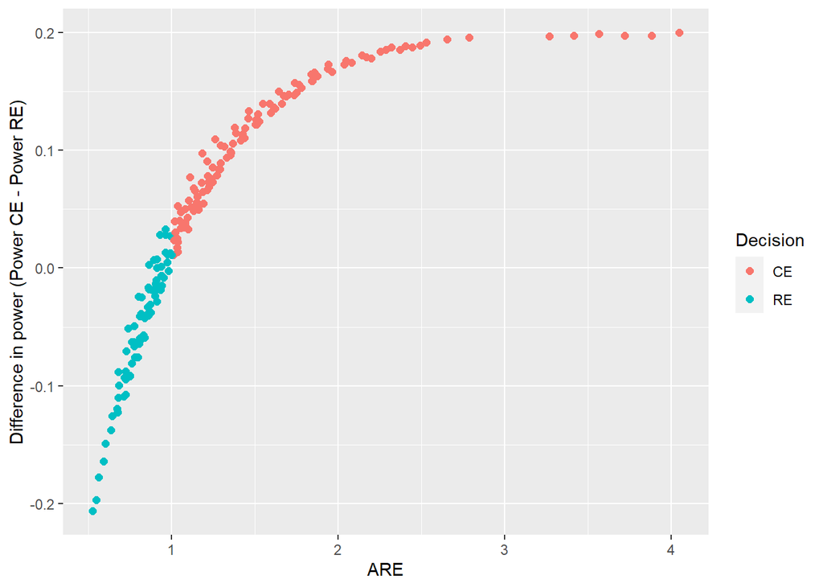

```r
dataset$diff_powers = dataset$Test_Power_CE - dataset$Test_Power_RE
ggplot(dataset, aes(x=ARE, y=diff_powers, color=as.factor(decision))) + geom_point(size=2) + labs(y = "Difference in power (Power CE - Power RE)", x="ARE", color="Decision")
```

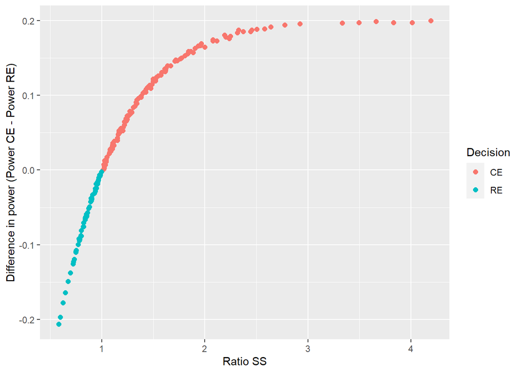

```r
# dataset$diff_powers = dataset$Test_Power_CE - dataset$Test_Power_RE
ggplot(dataset, aes(x=ss_ratio, y=diff_powers, color=as.factor(ss_decision))) + geom_point(size=2) + labs(y = "Difference in power (Power CE - Power RE)", x="Ratio SS", color="Decision")
```

# 5 Conclusions and future directions

Conclusions:

Future steps:

- Consider an interim stage to estimate the probabilities under the control group and the correlation.